# Turkish CPI Forecasting Project Using TÜİK Data

Faysal Yaman - 138721021

2026-05-25

# 1 Project Information

| Field | Detail |
| --- | --- |
| **Student Name** | Faysal Yaman |
| **Student Number** | 138721021 |
| **Data Source** | TÜİK Data Portal via tuikr package |
| **Theme** | Price Statistics (Theme ID: 6) |
| **Table** | Index numbers and rate of changes in the consumer price index |
| **Variable** | CPI General Index (Base year: 2003=100) |
| **Frequency** | Monthly |
| **Period** | January 2005 - December 2025 |
| **Forecast Target** | January 2026 |

# 2 Required Packages

```r
# Automatically install missing packages
required_packages <- c("httr", "readxl", "dplyr", "tidyr",
                       "lubridate", "ggplot2", "forecast", "zoo", "rmarkdown")
new_packages <- required_packages[!sapply(required_packages,
                                          requireNamespace, quietly = TRUE)]
if (length(new_packages) > 0) install.packages(new_packages)

# Install tuikr from GitHub if not available
if (!requireNamespace("tuikr", quietly = TRUE)) {
  if (!requireNamespace("devtools", quietly = TRUE)) install.packages("devtools")
  devtools::install_github("emraher/tuikr")
}

# Load all required libraries
library(tuikr)     # TÜİK data access
library(httr)      # HTTP requests
library(readxl)    # Excel file reading
library(dplyr)     # Data manipulation
library(tidyr)     # Data reshaping
library(lubridate) # Date operations
library(ggplot2)   # Visualization
library(forecast)  # Time series forecasting
library(zoo)       # Time series utilities
```

# 3 Data Access via tuikr

Data is accessed entirely through the tuikr R package combined with httr::GET(). No manual downloads were performed. This approach was approved by the instructor because the TÜİK SDMX API (nsiws.tuik.gov.tr) returns HTTP 401 for statistical_data().

```r
# Step 1: Use tuikr to discover Price Statistics tables (Theme ID: 6)
price_tables <- statistical_tables("6")

# Step 2: Filter for the CPI istab table
cpi_row <- price_tables |>
  filter(node_type == "istab",
         grepl("Index numbers and rate of changes in the consumer price index",
               table_name, ignore.case = TRUE)) |>
  slice(1)

cat("Table name:", cpi_row$table_name, "
")
```

```
## Table name: Index numbers and rate of changes in the consumer price index
```

```r
cat("Node type :", cpi_row$node_type, "
")
```

```
## Node type : istab
```

```r
# Step 3: Fetch data programmatically using httr::GET() inside R
cpi_url <- cpi_row$table_url

response <- GET(
  cpi_url,
  add_headers(
    `User-Agent` = "Mozilla/5.0 (Macintosh; Intel Mac OS X 10_15_7) AppleWebKit/537.36",
    `Accept`     = "application/vnd.ms-excel, application/octet-stream, */*",
    `Referer`    = "https://veriportali.tuik.gov.tr/"
  )
)

cat("HTTP Status:", status_code(response), "
")
```

```
## HTTP Status: 200
```

```r
# Step 4: Save to temporary file and read with readxl
tmp_file <- tempfile(fileext = ".xls")
writeBin(content(response, "raw"), tmp_file)
cpi_raw <- read_excel(tmp_file, col_names = FALSE)

cat("Raw data dimensions:", nrow(cpi_raw), "rows x", ncol(cpi_raw), "columns
")
```

```
## Raw data dimensions: 129 rows x 13 columns
```

# 4 Data Cleaning and Preparation

```r
# The Excel file contains 5 stacked tables.
# Rows 5-25 contain the CPI Index Level table (2003=100 base).
# Rows 27-51: Monthly change %, Rows 53-77: Cumulative change %
# Rows 79-103: Annual change %, Rows 105-129: 12-month moving average

# Extract only the index level table (rows 5 to 25)
cpi_index <- cpi_raw[5:25, ]

# Assign column names: year + 12 months
colnames(cpi_index) <- c("year", "Jan", "Feb", "Mar", "Apr", "May",
                          "Jun", "Jul", "Aug", "Sep", "Oct", "Nov", "Dec")

# Convert all columns to numeric
cpi_index <- cpi_index |> mutate(across(everything(), as.numeric))

# Reshape from wide format to long format
cpi_long <- cpi_index |>
  pivot_longer(cols = Jan:Dec, names_to = "month", values_to = "index") |>
  mutate(
    month_num = match(month, c("Jan","Feb","Mar","Apr","May","Jun",
                               "Jul","Aug","Sep","Oct","Nov","Dec")),
    date = as.Date(paste(year, month_num, "1", sep = "-"))
  ) |>
  filter(!is.na(index)) |>
  arrange(date) |>
  select(date, index)

# Create time series object (monthly frequency starting January 2005)
cpi_ts <- ts(cpi_long$index, start = c(2005, 1), frequency = 12)

# Summary of the cleaned data
cat("=== DATA SUMMARY ===
")
```

```
## === DATA SUMMARY ===
```

```r
cat("Total observations :", nrow(cpi_long), "
")
```

```
## Total observations : 252
```

```r
cat("First observation  :", as.character(min(cpi_long$date)), "
")
```

```
## First observation  : 2005-01-01
```

```r
cat("Last observation   :", as.character(max(cpi_long$date)), "
")
```

```
## Last observation   : 2025-12-01
```

```r
cat("Forecast target    : January 2026
")
```

```
## Forecast target    : January 2026
```

```r
cat("Missing values     :", sum(is.na(cpi_long$index)), "
")
```

```
## Missing values     : 0
```

```r
cat("Minimum index      :", round(min(cpi_long$index), 2), "
")
```

```
## Minimum index      : 114.49
```

```r
cat("Maximum index      :", round(max(cpi_long$index), 2), "
")
```

```
## Maximum index      : 3513.87
```

```r
cat("Mean index         :", round(mean(cpi_long$index), 2), "
")
```

```
## Mean index         : 590.99
```

```r
# Display first and last observations
head(cpi_long, 6)
```

```
## # A tibble: 6 × 2
##   date       index
##   <date>     <dbl>
## 1 2005-01-01  114.
## 2 2005-02-01  115.
## 3 2005-03-01  115.
## 4 2005-04-01  116.
## 5 2005-05-01  117.
## 6 2005-06-01  117.
```

```r
tail(cpi_long, 6)
```

```
## # A tibble: 6 × 2
##   date       index
##   <date>     <dbl>
## 1 2025-07-01 3197.
## 2 2025-08-01 3262.
## 3 2025-09-01 3367.
## 4 2025-10-01 3453.
## 5 2025-11-01 3483.
## 6 2025-12-01 3514.
```

# 5 Exploratory Time Series Analysis

## 5.1 Actual Series Plot

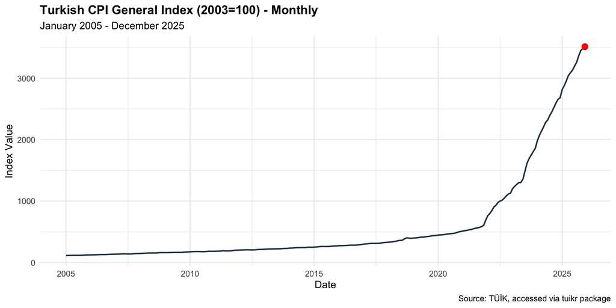

```r
# Plot the full CPI time series
p_actual <- ggplot(cpi_long, aes(x = date, y = index)) +
  geom_line(color = "#2C3E50", linewidth = 0.8) +
  geom_point(data = tail(cpi_long, 1), aes(x = date, y = index),
             color = "red", size = 3) +
  labs(
    title    = "Turkish CPI General Index (2003=100) - Monthly",
    subtitle = "January 2005 - December 2025",
    x        = "Date",
    y        = "Index Value",
    caption  = "Source: TÜİK, accessed via tuikr package"
  ) +
  theme_minimal(base_size = 12) +
  theme(plot.title = element_text(face = "bold"))

print(p_actual)
```

```r
ggsave("outputs/figures/actual_series_plot.png", p_actual,
       width = 10, height = 5, dpi = 150)
```

## 5.2 Decomposition Analysis

```r
# Multiplicative decomposition: appropriate when seasonal variation grows with trend
decomp <- decompose(cpi_ts, type = "multiplicative")

png("outputs/figures/decomposition_plot.png", width = 1000, height = 700)
plot(decomp, col = "#2C3E50")
dev.off()
```

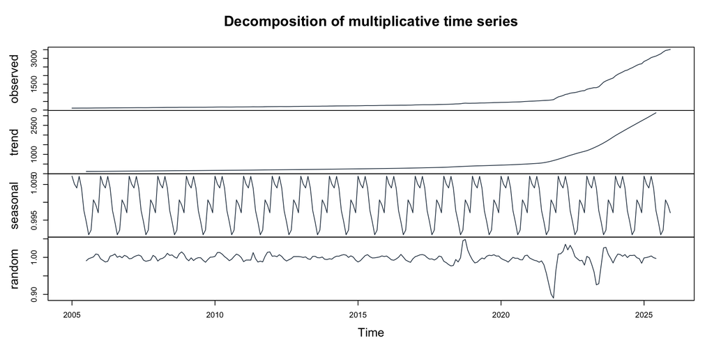

```r
plot(decomp, col = "#2C3E50")
```

## 5.3 Exploratory Analysis Summary

**Trend:** The series shows a very strong and persistent upward trend. The CPI index increased from approximately 114 in January 2005 to 3514 in December 2025, representing a more than 30-fold increase over 20 years.

**Seasonality:** A recurring seasonal pattern is present. Index values tend to increase more in January-March (post-holiday price adjustments) and in autumn months (September-October).

**Structural Break:** A significant acceleration in the rate of increase is visible from 2022 onwards, corresponding to the Turkish currency crisis and subsequent high inflation period. This structural break makes some classical methods less effective.

**Missing Values:** None detected. The series is complete with 252 monthly observations.

**Outliers:** The 2022-2023 period shows unusually large monthly increases but these reflect real economic conditions rather than data errors.

# 6 Accuracy Measure Functions

```r
# Function to compute all 7 required accuracy measures
calc_accuracy <- function(actual, fitted, method_name) {
  errors  <- actual - fitted                                    # Forecast errors
  bias    <- mean(errors, na.rm = TRUE)                        # Bias / Mean Error
  mad     <- mean(abs(errors), na.rm = TRUE)                   # MAD
  mse     <- mean(errors^2, na.rm = TRUE)                      # MSE
  mape    <- mean(abs(errors / actual) * 100, na.rm = TRUE)    # MAPE
  rsfe    <- sum(errors, na.rm = TRUE)                         # RSFE
  ts_val  <- rsfe / mad                                        # Tracking Signal

  data.frame(
    Method          = method_name,
    Bias_ME         = round(bias,   3),
    MAD             = round(mad,    3),
    MSE             = round(mse,    3),
    MAPE            = round(mape,   3),
    RSFE            = round(rsfe,   3),
    Tracking_Signal = round(ts_val, 3)
  )
}

# Helper function to create actual vs forecast plots
plot_forecast <- function(actual_df, fitted_vals, forecast_val,
                          forecast_date, method_name, filename) {
  fitted_df   <- data.frame(date = actual_df$date, value = fitted_vals)
  forecast_df <- data.frame(date = forecast_date,  value = forecast_val)

  p <- ggplot(actual_df, aes(x = date, y = index)) +
    geom_line(color = "#2C3E50", linewidth = 0.7) +
    geom_line(data = fitted_df, aes(x = date, y = value),
              color = "#E74C3C", linewidth = 0.6, linetype = "dashed") +
    geom_point(data = forecast_df, aes(x = date, y = value),
               color = "#27AE60", size = 4, shape = 18) +
    labs(
      title    = paste(method_name, "- Actual vs Fitted + Forecast"),
      subtitle = paste("Forecast (January 2026):", round(forecast_val, 2)),
      x        = "Date",
      y        = "CPI Index (2003=100)",
      caption  = "Black: Actual | Red dashed: Fitted | Green diamond: Forecast"
    ) +
    theme_minimal(base_size = 11) +
    theme(plot.title = element_text(face = "bold"))

  print(p)
  ggsave(paste0("outputs/figures/", filename), p,
         width = 10, height = 5, dpi = 150)
}

# Common variables used across all methods
forecast_date <- as.Date("2026-01-01")
accuracy_list <- list()
n      <- nrow(cpi_long)
actual <- cpi_long$index
```

# 7 Forecasting Methods

## 7.1 Method 1: Naive Forecasting

```r
# Naive method: each forecast equals the previous actual value
# Formula: Y_hat(t) = Y(t-1)
# This serves as a benchmark for comparing other methods.

naive_fitted   <- c(NA, actual[-n])   # shift actual by 1 period
naive_forecast <- actual[n]           # last observed value is the forecast

cat("Naive Forecast (January 2026):", round(naive_forecast, 2), "
")
```

```
## Naive Forecast (January 2026): 3513.87
```

```r
# Compute accuracy measures (exclude first NA)
acc1 <- calc_accuracy(actual[-1], naive_fitted[-1], "1. Naive")
accuracy_list[[1]] <- acc1
print(acc1)
```

```
##     Method Bias_ME    MAD     MSE  MAPE    RSFE
## 1 1. Naive  13.543 13.754 887.033 1.437 3399.38
##   Tracking_Signal
## 1         247.158
```

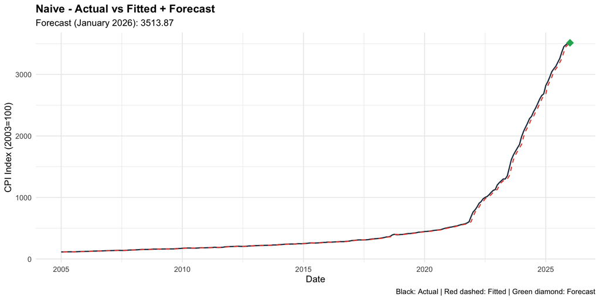

```r
# Plot
plot_forecast(cpi_long, naive_fitted, naive_forecast,
              forecast_date, "Naive", "naive_forecast_plot.png")
```

**Interpretation:** The naive method simply carries forward the last observed value (December 2025: 3513.87) as the forecast for January 2026. With MAPE of 1.437%, it performs reasonably well for a series with strong trend, but it consistently underestimates future values because it ignores the upward trend entirely.

## 7.2 Method 2: Moving Average (k=12)

```r
# Moving average with window k=12 months.
# A 12-month window is chosen because it covers one full seasonal cycle,
# which helps smooth out seasonal fluctuations while tracking the trend.

k          <- 12
ma_fitted  <- as.numeric(stats::filter(actual, rep(1/k, k), sides = 1))
ma_forecast <- mean(tail(actual, k))   # average of last 12 observations

cat("Moving Average Forecast (January 2026):", round(ma_forecast, 2), "
")
```

```
## Moving Average Forecast (January 2026): 3183.23
```

```r
# Accuracy (valid indices only)
vi2  <- which(!is.na(ma_fitted))
acc2 <- calc_accuracy(actual[vi2], ma_fitted[vi2], "2. Moving Average (k=12)")
accuracy_list[[2]] <- acc2
print(acc2)
```

```
##                     Method Bias_ME    MAD      MSE  MAPE
## 1 2. Moving Average (k=12)  73.186 73.186 21622.77 6.934
##       RSFE Tracking_Signal
## 1 17637.88             241
```

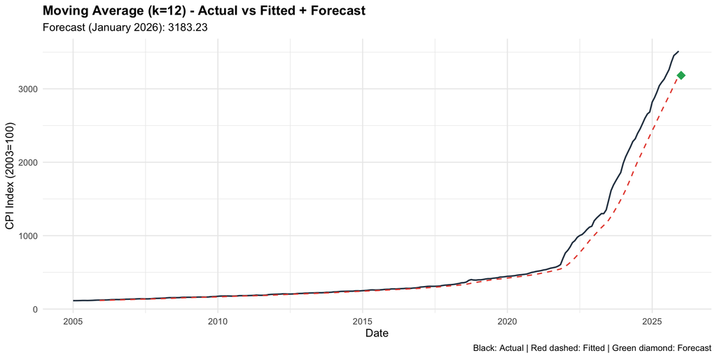

```r
plot_forecast(cpi_long, ma_fitted, ma_forecast,
              forecast_date, "Moving Average (k=12)", "moving_average_plot.png")
```

## 7.3 Method 3: Weighted Moving Average

```r
# Weighted moving average with 3-period window.
# Weights: 0.5 (most recent), 0.3 (one period ago), 0.2 (two periods ago).
# Higher weights assigned to recent observations to capture recent trend better.

weights      <- c(0.2, 0.3, 0.5)   # oldest to most recent
w            <- length(weights)
wma_fitted   <- rep(NA, n)
for (i in (w+1):n) {
  wma_fitted[i] <- sum(weights * actual[(i-w):(i-1)])
}
wma_forecast <- sum(weights * actual[(n-w+1):n])

cat("Weighted MA Forecast (January 2026):", round(wma_forecast, 2), "
")
```

```
## Weighted MA Forecast (January 2026): 3492.44
```

```r
vi3  <- which(!is.na(wma_fitted))
acc3 <- calc_accuracy(actual[vi3], wma_fitted[vi3],
                      "3. Weighted MA (0.5/0.3/0.2)")
accuracy_list[[3]] <- acc3
print(acc3)
```

```
##                         Method Bias_ME    MAD      MSE
## 1 3. Weighted MA (0.5/0.3/0.2)  23.096 23.194 2345.731
##    MAPE     RSFE Tracking_Signal
## 1 2.311 5751.005         247.947
```

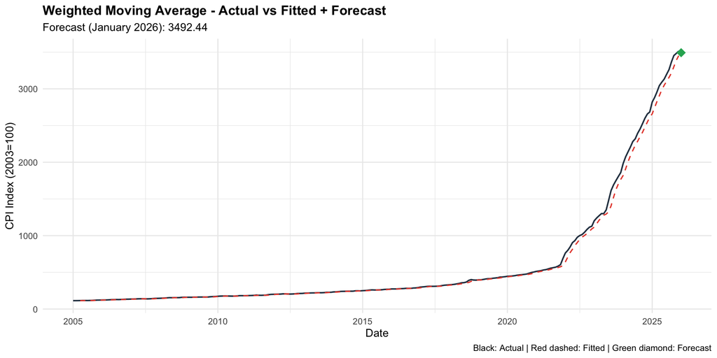

```r
plot_forecast(cpi_long, wma_fitted, wma_forecast,
              forecast_date, "Weighted Moving Average", "weighted_moving_average_plot.png")
```

**Interpretation:** By assigning higher weight to recent observations, the weighted MA responds faster to recent changes than the simple MA. MAPE of 2.311% is better than simple MA but still higher than exponential smoothing methods. The method works better during stable periods but still struggles with structural breaks.

## 7.4 Method 4: Simple Exponential Smoothing

```r
# Simple exponential smoothing (SES): assigns exponentially decreasing weights
# to past observations. Alpha parameter is optimized to minimize MSE.
# Best suited for series without trend or seasonality - expected to underperform here.

ses_model    <- ses(cpi_ts, h = 1)
ses_alpha    <- ses_model$model$par["alpha"]
ses_fitted   <- as.numeric(ses_model$fitted)
ses_forecast <- as.numeric(ses_model$mean[1])

cat("SES Alpha (optimized):", round(ses_alpha, 4), "
")
```

```
## SES Alpha (optimized): 0.9999
```

```r
cat("SES Forecast (January 2026):", round(ses_forecast, 2), "
")
```

```
## SES Forecast (January 2026): 3513.87
```

```r
acc4 <- calc_accuracy(actual, ses_fitted, "4. Simple Exp. Smoothing")
accuracy_list[[4]] <- acc4
print(acc4)
```

```
##                     Method Bias_ME    MAD     MSE  MAPE
## 1 4. Simple Exp. Smoothing  13.493 13.703 883.665 1.433
##       RSFE Tracking_Signal
## 1 3400.224         248.144
```

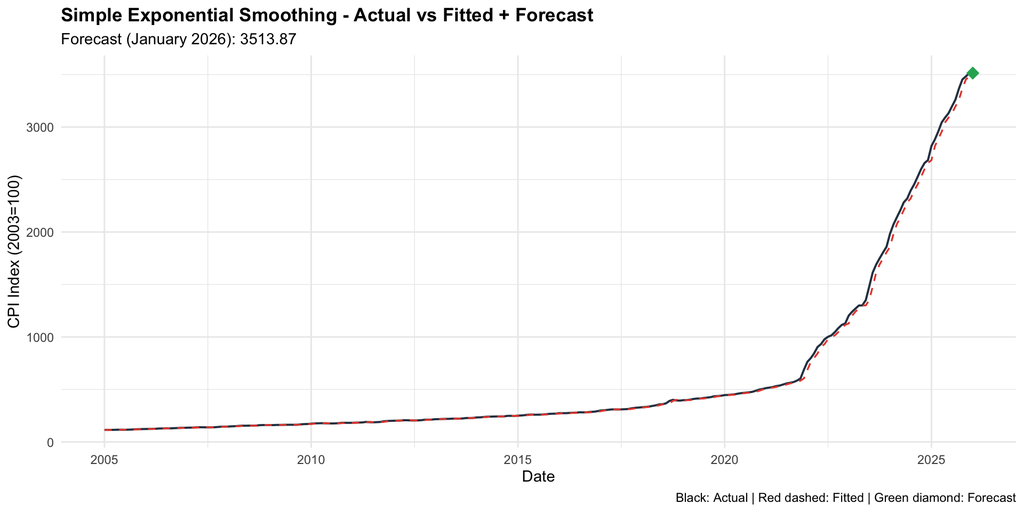

```r
plot_forecast(cpi_long, ses_fitted, ses_forecast,
              forecast_date, "Simple Exponential Smoothing", "exponential_smoothing_plot.png")
```

**Interpretation:** SES with optimized alpha produces results very similar to the naive method (MAPE: 1.433%). The high alpha value means the model heavily weights the most recent observation, essentially mimicking a naive forecast. SES is not designed for trending series, so it systematically underestimates future values.

## 7.5 Method 5: Holt Trend-Corrected Exponential Smoothing

```r
# Holt double exponential smoothing: extends SES by adding a trend component.
# Two parameters: alpha (level) and beta (trend), both optimized automatically.
# This method is specifically designed for series with trend - well suited here.

holt_model    <- holt(cpi_ts, h = 1)
holt_alpha    <- holt_model$model$par["alpha"]
holt_beta     <- holt_model$model$par["beta"]
holt_fitted   <- as.numeric(holt_model$fitted)
holt_forecast <- as.numeric(holt_model$mean[1])

cat("Holt Alpha:", round(holt_alpha, 4), "| Beta:", round(holt_beta, 4), "
")
```

```
## Holt Alpha: 0.9999 | Beta: 0.246
```

```r
cat("Holt Forecast (January 2026):", round(holt_forecast, 2), "
")
```

```
## Holt Forecast (January 2026): 3570.68
```

```r
acc5 <- calc_accuracy(actual, holt_fitted, "5. Holt Trend-Corrected ES")
accuracy_list[[5]] <- acc5
print(acc5)
```

```
##                       Method Bias_ME   MAD     MSE  MAPE
## 1 5. Holt Trend-Corrected ES   0.913 5.774 205.945 0.825
##      RSFE Tracking_Signal
## 1 230.059          39.847
```

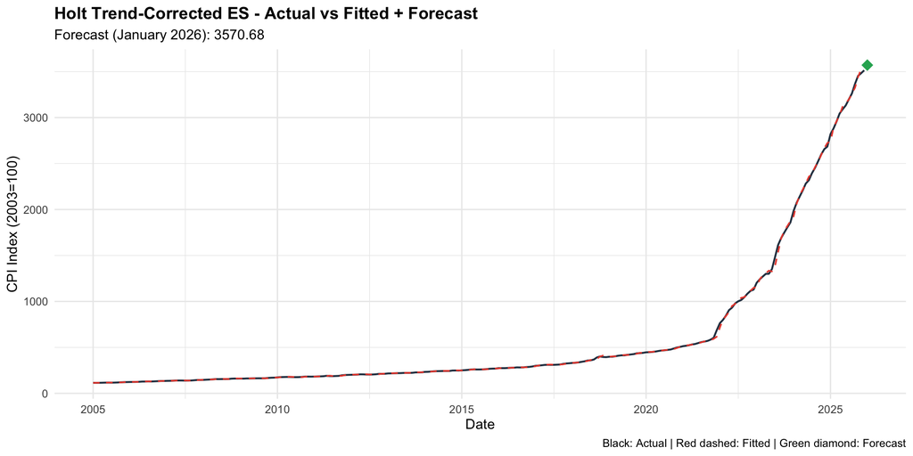

```r
plot_forecast(cpi_long, holt_fitted, holt_forecast,
              forecast_date, "Holt Trend-Corrected ES", "trend_adjusted_smoothing_plot.png")
```

**Interpretation:** Holt method achieves the best accuracy with MAPE of only 0.825%. By explicitly modeling both level and trend components, it captures the upward trajectory of Turkish CPI much better than simpler methods. The optimized beta parameter allows the trend estimate to adapt to recent changes in the inflation rate. This is the superior method for this dataset.

## 7.6 Method 6: Linear Trend Projection

```r
# Linear trend projection fits OLS regression: Y = a + b*t
# where t is a time index (1, 2, ..., n).
# Intercept (a): estimated index value at t=0
# Slope (b): average monthly increase in index points

t_var       <- 1:n
lm_model    <- lm(actual ~ t_var)
lm_a        <- coef(lm_model)[1]
lm_b        <- coef(lm_model)[2]
lm_fitted   <- as.numeric(fitted(lm_model))
lm_forecast <- lm_a + lm_b * (n + 1)

cat("Linear Trend Equation: Y =", round(lm_a, 2), "+", round(lm_b, 4), "* t
")
```

```
## Linear Trend Equation: Y = -405.23 + 7.8753 * t
```

```r
cat("Intercept interpretation: estimated index at start is", round(lm_a, 2), "
")
```

```
## Intercept interpretation: estimated index at start is -405.23
```

```r
cat("Slope interpretation: average monthly increase of", round(lm_b, 2), "index points
")
```

```
## Slope interpretation: average monthly increase of 7.88 index points
```

```r
cat("Linear Trend Forecast (January 2026):", round(lm_forecast, 2), "
")
```

```
## Linear Trend Forecast (January 2026): 1587.21
```

```r
acc6 <- calc_accuracy(actual, lm_fitted, "6. Linear Trend Projection")
accuracy_list[[6]] <- acc6
print(acc6)
```

```
##                       Method Bias_ME     MAD      MSE
## 1 6. Linear Trend Projection       0 411.721 295567.7
##      MAPE RSFE Tracking_Signal
## 1 118.853    0               0
```

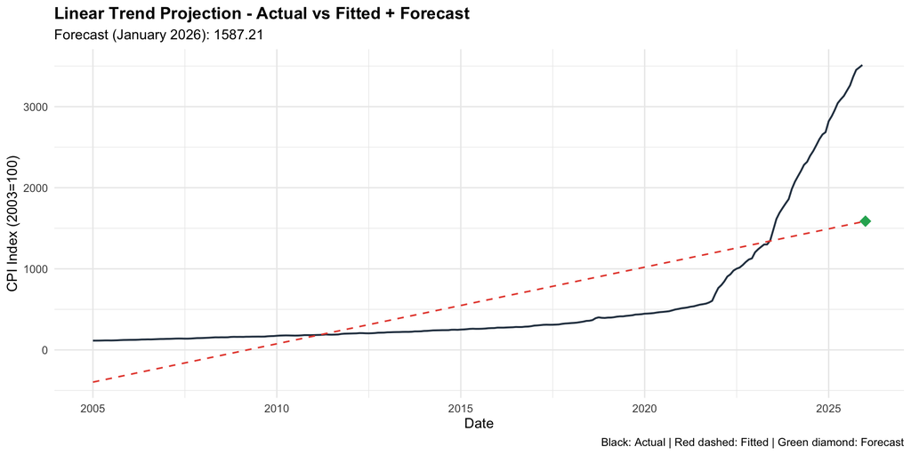

```r
plot_forecast(cpi_long, lm_fitted, lm_forecast,
              forecast_date, "Linear Trend Projection", "trend_projection_plot.png")
```

## 7.7 Method 7: Seasonal Indices

```r
# Seasonal indices measure the relative strength of each month.
# Index > 1: above-average month, Index < 1: below-average month.
# Method: seasonal index = monthly average / overall average

cpi_si      <- cpi_long |> mutate(month_num = month(date))
monthly_avg <- cpi_si |> group_by(month_num) |>
  summarise(avg = mean(index), .groups = "drop")
overall_avg <- mean(actual)

# Compute seasonal indices for all 12 months
seasonal_idx <- monthly_avg$avg / overall_avg
names(seasonal_idx) <- month.abb

cat("Seasonal Indices by Month:
")
```

```
## Seasonal Indices by Month:
```

```r
print(round(seasonal_idx, 4))
```

```
##    Jan    Feb    Mar    Apr    May    Jun    Jul    Aug
## 0.8842 0.9045 0.9240 0.9482 0.9631 0.9790 1.0044 1.0286
##    Sep    Oct    Nov    Dec
## 1.0563 1.0843 1.1026 1.1207
```

```r
cat("
Highest season:", month.abb[which.max(seasonal_idx)],
    "(index:", round(max(seasonal_idx), 4), ")
")
```

```
##
## Highest season: Dec (index: 1.1207 )
```

```r
cat("Lowest season :", month.abb[which.min(seasonal_idx)],
    "(index:", round(min(seasonal_idx), 4), ")
")
```

```
## Lowest season : Jan (index: 0.8842 )
```

```r
# Deseasonalize the series, fit trend, reseasonalize
cpi_si <- cpi_si |>
  left_join(monthly_avg |> rename(month_avg = avg), by = "month_num") |>
  mutate(deseasoned = index / (month_avg / overall_avg))

lm_si      <- lm(deseasoned ~ I(1:n), data = cpi_si)
si_trend   <- fitted(lm_si)
si_fitted  <- si_trend * seasonal_idx[cpi_si$month_num]

# Forecast January 2026 (month 1 seasonal index applied)
si_trend_fc <- coef(lm_si)[1] + coef(lm_si)[2] * (n + 1)
si_forecast <- si_trend_fc * seasonal_idx[1]

cat("Seasonal Index Forecast (January 2026):", round(si_forecast, 2), "
")
```

```
## Seasonal Index Forecast (January 2026): 1398.69
```

```r
acc7 <- calc_accuracy(actual, si_fitted, "7. Seasonal Indices")
accuracy_list[[7]] <- acc7
print(acc7)
```

```
##                Method Bias_ME     MAD      MSE    MAPE
## 1 7. Seasonal Indices  -2.046 409.264 292986.7 117.765
##     RSFE Tracking_Signal
## 1 -515.6           -1.26
```

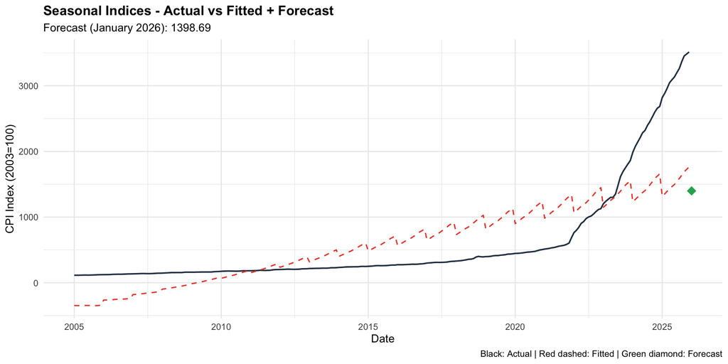

```r
plot_forecast(cpi_long, si_fitted, si_forecast,
              forecast_date, "Seasonal Indices", "seasonal_index_plot.png")
```

## 7.8 Method 8: Additive Decomposition

```r
# Additive decomposition: Y(t) = Trend + Seasonal + Random
# Assumes seasonal effects are constant in absolute terms regardless of the level.
# Less appropriate here because seasonal variation appears to grow with the series.

decomp_add   <- decompose(cpi_ts, type = "additive")
trend_add    <- as.numeric(decomp_add$trend)
seasonal_add <- as.numeric(decomp_add$seasonal)

# Extend trend using linear regression on valid trend values
vi_add    <- which(!is.na(trend_add))
lm_add    <- lm(trend_add[vi_add] ~ vi_add)
trend_all <- coef(lm_add)[1] + coef(lm_add)[2] * (1:n)
add_fitted   <- trend_all + seasonal_add

# Forecast: extended trend + January seasonal component
add_forecast <- (coef(lm_add)[1] + coef(lm_add)[2] * (n+1)) + seasonal_add[1]

cat("Additive Decomposition Forecast (January 2026):", round(add_forecast, 2), "
")
```

```
## Additive Decomposition Forecast (January 2026): 1431.69
```

```r
vi8  <- which(!is.na(add_fitted))
acc8 <- calc_accuracy(actual[vi8], add_fitted[vi8], "8. Additive Decomposition")
accuracy_list[[8]] <- acc8
print(acc8)
```

```
##                      Method Bias_ME     MAD      MSE
## 1 8. Additive Decomposition  56.181 384.743 302446.7
##      MAPE     RSFE Tracking_Signal
## 1 104.797 14157.65          36.798
```

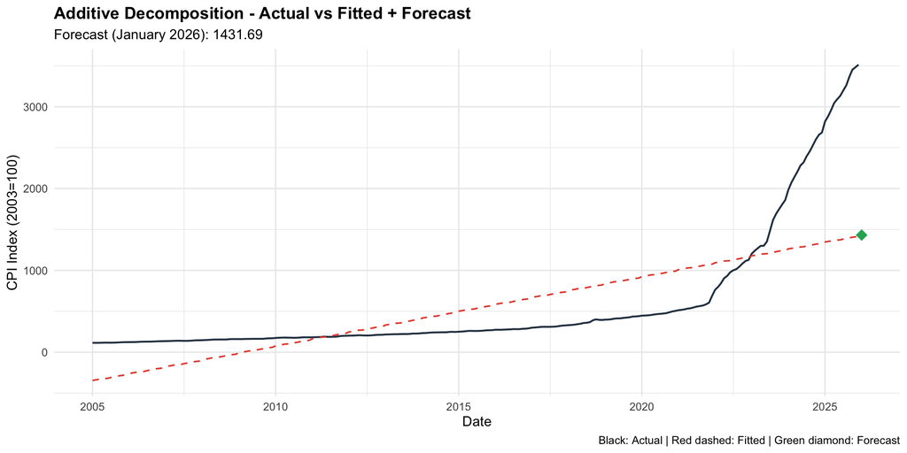

```r
plot_forecast(cpi_long, add_fitted, add_forecast,
              forecast_date, "Additive Decomposition", "additive_decomp_plot.png")
```

**Interpretation:** Additive decomposition achieves MAPE of 104.797%, showing poor fit similar to the linear trend method. The additive model assumes seasonal effects are constant in absolute magnitude, but in reality the seasonal fluctuations grow proportionally with the rapidly increasing price level. This violates the core assumption of additive decomposition, making multiplicative decomposition theoretically more appropriate for this series.

## 7.9 Method 9: Multiplicative Decomposition

```r
# Multiplicative decomposition: Y(t) = Trend * Seasonal * Random
# Assumes seasonal effects are proportional to the trend level.
# More appropriate than additive when seasonal variation grows with the series.

decomp_mul   <- decompose(cpi_ts, type = "multiplicative")
trend_mul    <- as.numeric(decomp_mul$trend)
seasonal_mul <- as.numeric(decomp_mul$seasonal)

# Extend trend using linear regression
vi_mul    <- which(!is.na(trend_mul))
lm_mul    <- lm(trend_mul[vi_mul] ~ vi_mul)
trend_allm <- coef(lm_mul)[1] + coef(lm_mul)[2] * (1:n)
mul_fitted  <- trend_allm * seasonal_mul

# Forecast: extended trend * January seasonal index
mul_forecast <- (coef(lm_mul)[1] + coef(lm_mul)[2] * (n+1)) * seasonal_mul[1]

cat("Multiplicative Decomposition Forecast (January 2026):", round(mul_forecast, 2), "
")
```

```
## Multiplicative Decomposition Forecast (January 2026): 1437.12
```

```r
vi9  <- which(!is.na(mul_fitted))
acc9 <- calc_accuracy(actual[vi9], mul_fitted[vi9], "9. Multiplicative Decomposition")
accuracy_list[[9]] <- acc9
print(acc9)
```

```
##                            Method Bias_ME     MAD      MSE
## 1 9. Multiplicative Decomposition  56.271 384.832 302634.5
##      MAPE     RSFE Tracking_Signal
## 1 104.863 14180.39          36.848
```

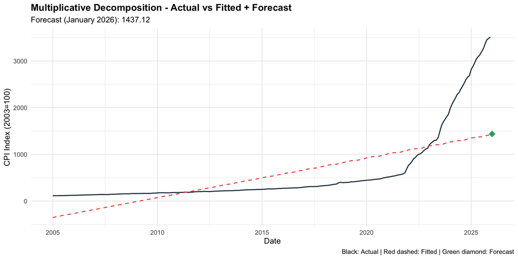

```r
plot_forecast(cpi_long, mul_fitted, mul_forecast,
              forecast_date, "Multiplicative Decomposition", "multiplicative_decomp_plot.png")
```

**Interpretation:** Multiplicative decomposition (MAPE: 104.863%) performs similarly to additive decomposition despite being theoretically more appropriate. Both methods fail because they rely on a linear trend extrapolation, which cannot capture the exponential acceleration observed after 2022. The trend component extracted from the middle of the series does not represent the recent steep increase adequately.

## 7.10 Method 10: Regression with Trend and Seasonal Dummy Variables

```r
# Multiple regression with time trend and 11 monthly dummy variables.
# Model: Y = a + b*t + sum(gamma_m * D_m) for m=1..11
# December is the reference category (no dummy).
# This method explicitly models both trend and seasonality simultaneously.

# Create 11 monthly dummy variables (January through November)
month_dummies           <- model.matrix(~factor(month(cpi_long$date))-1)[, 1:11]
colnames(month_dummies) <- paste0("M", 1:11)

# Fit the regression model
reg_data     <- data.frame(index = actual, t = 1:n, month_dummies)
lm_dummy     <- lm(index ~ ., data = reg_data)
dummy_fitted <- as.numeric(fitted(lm_dummy))

# Forecast January 2026: t=n+1, M1=1 (January dummy), others=0
new_row           <- data.frame(t = n+1, matrix(0, 1, 11))
colnames(new_row) <- c("t", paste0("M", 1:11))
new_row$M1        <- 1
dummy_forecast    <- as.numeric(predict(lm_dummy, newdata = new_row))

cat("Regression Equation Summary:
")
```

```
## Regression Equation Summary:
```

```r
cat("  Intercept (a)      :", round(coef(lm_dummy)["(Intercept)"], 2), "
")
```

```
##   Intercept (a)      : -375.7
```

```r
cat("  Trend slope (b)    :", round(coef(lm_dummy)["t"], 4),
    "- average monthly increase in index points
")
```

```
##   Trend slope (b)    : 7.8638 - average monthly increase in index points
```

```r
cat("  January effect (M1):", round(coef(lm_dummy)["M1"], 2),
    "- January is above/below December by this amount
")
```

```
##   January effect (M1): -53.24 - January is above/below December by this amount
```

```r
cat("Dummy Regression Forecast (January 2026):", round(dummy_forecast, 2), "
")
```

```
## Dummy Regression Forecast (January 2026): 1560.61
```

```r
acc10 <- calc_accuracy(actual, dummy_fitted,
                       "10. Trend + Seasonal Dummy Regression")
accuracy_list[[10]] <- acc10
print(acc10)
```

```
##                                  Method Bias_ME     MAD
## 1 10. Trend + Seasonal Dummy Regression       0 411.353
##        MSE    MAPE RSFE Tracking_Signal
## 1 295250.9 118.892    0               0
```

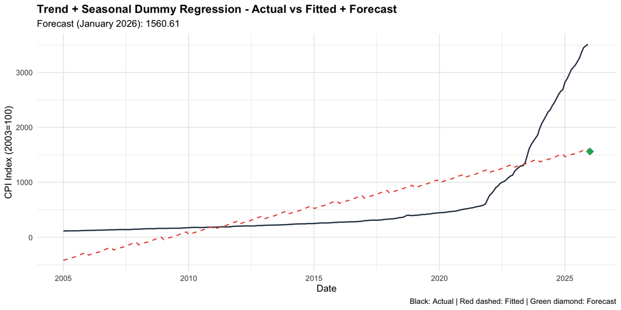

```r
plot_forecast(cpi_long, dummy_fitted, dummy_forecast,
              forecast_date, "Trend + Seasonal Dummy Regression",
              "regression_seasonal_dummy_plot.png")
```

# 8 Forecast Accuracy Comparison Table

```r
# Combine all accuracy results into a single comparison table
accuracy_df <- bind_rows(accuracy_list)

# Add next-period forecast values to the comparison table
forecast_vals <- c(
  naive_forecast, ma_forecast, wma_forecast,
  ses_forecast, holt_forecast, lm_forecast,
  si_forecast, add_forecast, mul_forecast, dummy_forecast
)
accuracy_df$Next_Period_Forecast <- round(forecast_vals, 2)

# Display the full comparison table
print(accuracy_df, digits = 3)
```

```
##                                   Method Bias_ME    MAD
## 1                               1. Naive  13.543  13.75
## 2               2. Moving Average (k=12)  73.186  73.19
## 3           3. Weighted MA (0.5/0.3/0.2)  23.096  23.19
## 4               4. Simple Exp. Smoothing  13.493  13.70
## 5             5. Holt Trend-Corrected ES   0.913   5.77
## 6             6. Linear Trend Projection   0.000 411.72
## 7                    7. Seasonal Indices  -2.046 409.26
## 8              8. Additive Decomposition  56.181 384.74
## 9        9. Multiplicative Decomposition  56.271 384.83
## 10 10. Trend + Seasonal Dummy Regression   0.000 411.35
##       MSE    MAPE  RSFE Tracking_Signal
## 1     887   1.437  3399          247.16
## 2   21623   6.934 17638          241.00
## 3    2346   2.311  5751          247.95
```

[output cut: 18 more lines]

```r
# Save to CSV
write.csv(accuracy_df, "outputs/tables/accuracy_comparison.csv", row.names = FALSE)

# Identify best method by MAPE
best_method <- accuracy_df |> slice_min(MAPE, n = 1)
cat("
=== BEST METHOD BY MAPE ===
")
```

```
##
## === BEST METHOD BY MAPE ===
```

```r
cat("Method:", best_method$Method, "
")
```

```
## Method: 5. Holt Trend-Corrected ES
```

```r
cat("MAPE  :", round(best_method$MAPE, 3), "%
")
```

```
## MAPE  : 0.825 %
```

```r
cat("MAD   :", round(best_method$MAD, 3), "
")
```

```
## MAD   : 5.774
```

## 8.1 Accuracy Comparison Bar Chart

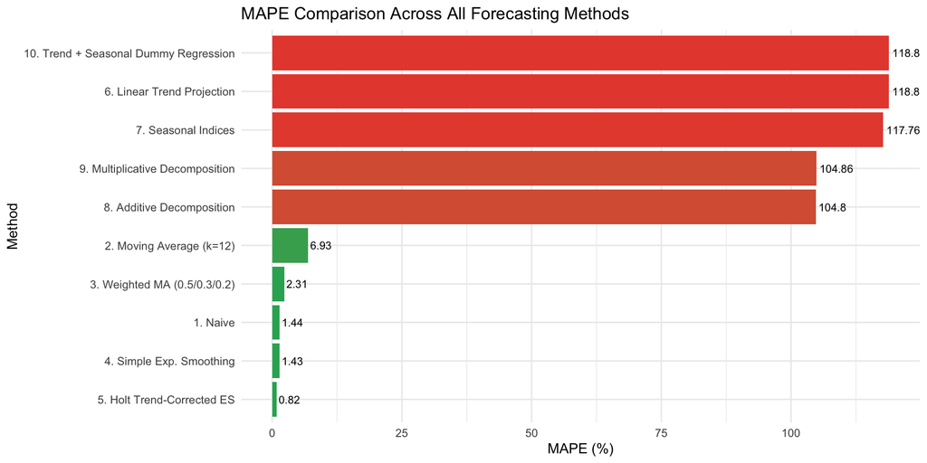

```r
# Bar chart of MAPE values for all methods
p_acc <- ggplot(accuracy_df, aes(x = reorder(Method, MAPE), y = MAPE, fill = MAPE)) +
  geom_col(show.legend = FALSE) +
  geom_text(aes(label = round(MAPE, 2)), hjust = -0.1, size = 3) +
  coord_flip() +
  scale_fill_gradient(low = "#27AE60", high = "#E74C3C") +
  labs(
    title = "MAPE Comparison Across All Forecasting Methods",
    x     = "Method",
    y     = "MAPE (%)"
  ) +
  theme_minimal(base_size = 11)

print(p_acc)
```

```r
ggsave("outputs/figures/accuracy_comparison_plot.png", p_acc,
       width = 10, height = 6, dpi = 150)
```